# Ski Case

## Load Data

```r
data.set <- read.csv("Whistler Blackcomb Exhibit1.csv", skip = 2)
data.set <- data.set[1:93, ]
colnames(data.set)[5] <- "Prebookings"
colnames(data.set)[6] <- "Actual.Demand"
colnames(data.set)[7] <- "Holiday"
colnames(data.set)[8] <- "Matched.DOW"
```

## Regression

#### Test Day-Matching Theory

Lets view the matched days as a time series

```r
library(plotly)
library(ggplot2)
names(data.set)
```

```
 [1] "Date"                  "Day.of.Season"         "Day.of.Week"           "Week.of.Season"
 [5] "Prebookings"           "Actual.Demand"         "Holiday"               "Matched.DOW"
 [9] "Exchange.Rate.USD.CAD" "Exchange.Rate.GBP.CAD"
```

```r
plot_ly(data.set, x = ~Day.of.Season, y = ~Actual.Demand,
        name = 'Actual Demand', type = 'scatter', mode = 'lines') %>%
  add_trace(y = ~Matched.DOW, name = 'Matched Day', mode = 'lines+markers')
```

[interactive chart not shown]

### Next Lets plot the days against eachother to see if there is some corrolation

```r
actualDemand <- data.set$Actual.Demand
matchedDemand <- data.set$Matched.DOW
plot(matchedDemand ~ actualDemand,
     xlab = "Actual Demand",
     ylab = "Past Demand 1998-1999",
     main = "Demand Matched on Day of Week",
     col = "blue")
m <- lm(matchedDemand ~ actualDemand)
abline(m, col="red")
```

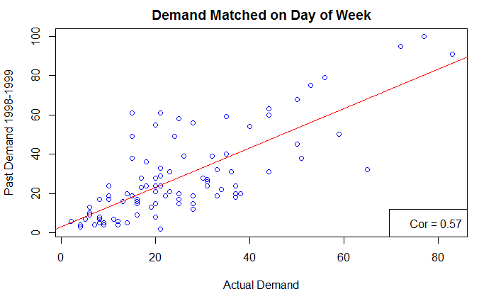

```r
legend(x='bottomright', legend=paste('Cor =',round(summary(m)$r.squared,2)))
```

### Make a function to filter each day and see if certain days match up better

```r
library(dplyr)
filterDays <- function(df, days = c("Mon", "Tue", "Wed", "Thu", "Fri", "Sat", "Sun")) {
  f <- filter(df, Day.of.Week == days)
  return(f)
}
```

### Loop through the days of the week to see if any days match up better

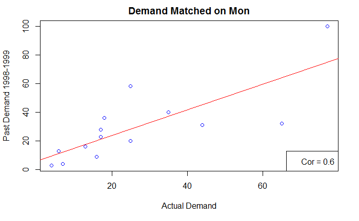

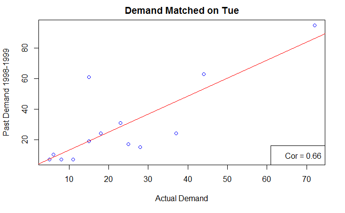

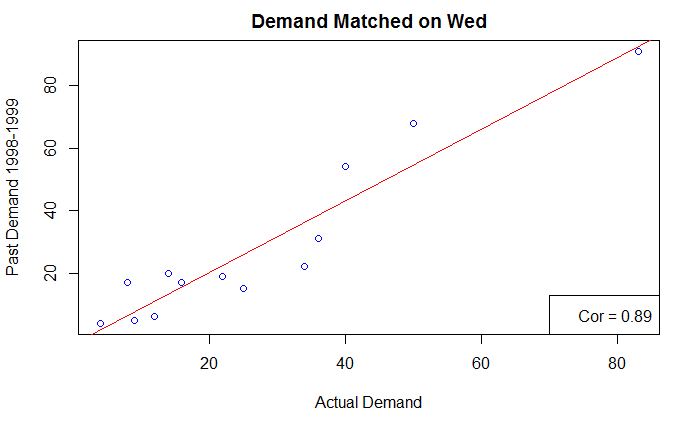

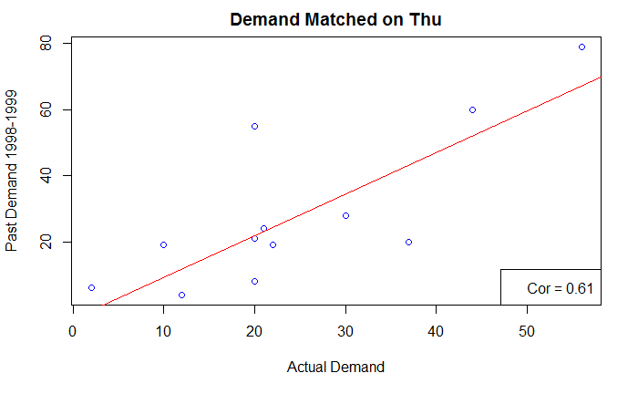

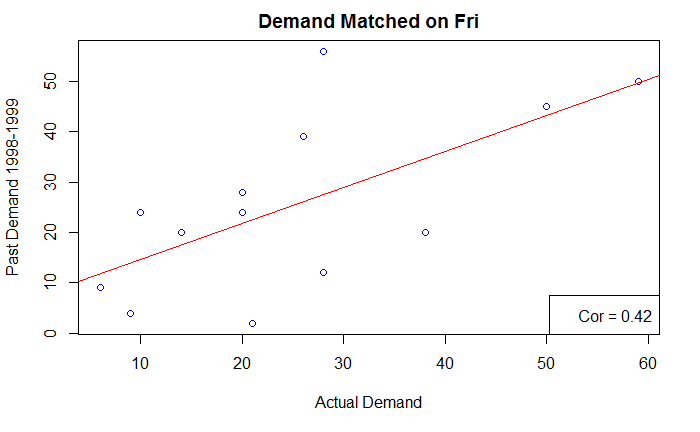

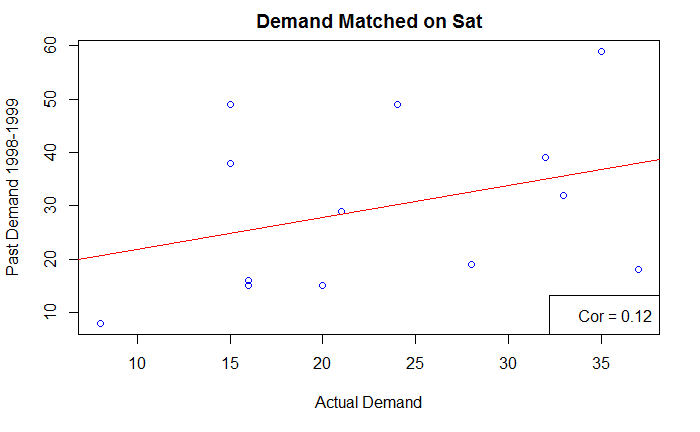

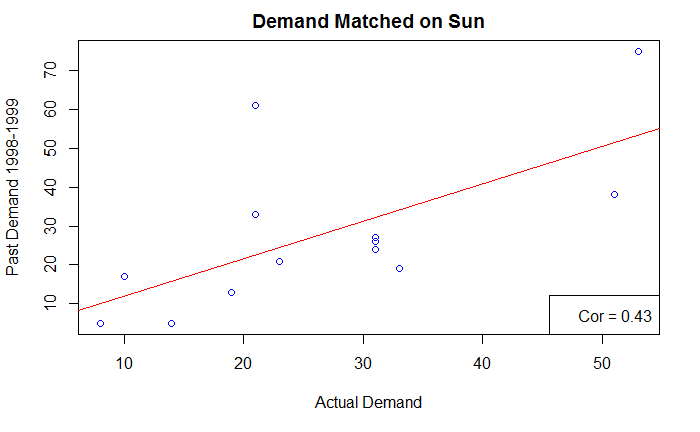

```r
days <- c("Mon", "Tue", "Wed", "Thu", "Fri", "Sat", "Sun")
for (i in 1:length(days)) {
  filtered <- filterDays(data.set, days[i])
  ad <- filtered$Actual.Demand
  md <- filtered$Matched.DOW
  plot(md ~ ad,
     xlab = "Actual Demand",
     ylab = "Past Demand 1998-1999",
     main = paste("Demand Matched on", days[i]),
     col = "blue")
  lm.filtered <- lm(md ~ ad)
  abline(lm.filtered, col="red")
  legend(x='bottomright', legend=paste('Cor =',round(summary(lm.filtered)$r.squared,2)))
}
```

### It looks like the middle of the week has better day-matching correlation, lets map r^2 values to check

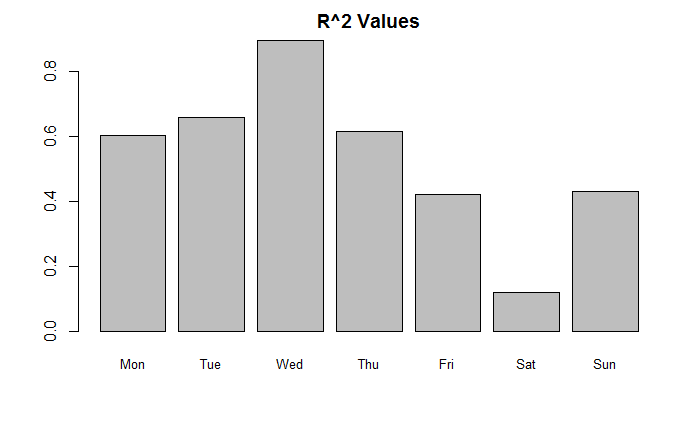

```r
r2Value <- NULL
for (i in 1:length(days)) {
  filtered <- filterDays(data.set, days[i])
  ad <- filtered$Actual.Demand
  md <- filtered$Matched.DOW
  lm.filtered <- lm(md ~ ad)
  r2 <- summary(lm.filtered)$r.squared
  r2Value <- c(r2Value, r2)
}
barplot(r2Value, main="R^2 Values", names.arg=days, cex.names=0.8)
```

### The weekend definitely isn’t a good time to use day matching to predict actual demand!!

# Linear Models with multiple variables

### use leaps to figure out the best variable to keep in the model

```r
library(leaps)
model.allsubsets <- regsubsets(Actual.Demand ~ Prebookings + Matched.DOW +
                                 Exchange.Rate.USD.CAD + Exchange.Rate.GBP.CAD,
                               data = data.set)
summary(model.allsubsets)
```

```
Subset selection object
Call: regsubsets.formula(Actual.Demand ~ Prebookings + Matched.DOW +
    Exchange.Rate.USD.CAD + Exchange.Rate.GBP.CAD, data = data.set)
4 Variables  (and intercept)
                      Forced in Forced out
Prebookings               FALSE      FALSE
Matched.DOW               FALSE      FALSE
Exchange.Rate.USD.CAD     FALSE      FALSE
Exchange.Rate.GBP.CAD     FALSE      FALSE
1 subsets of each size up to 4
Selection Algorithm: exhaustive
         Prebookings Matched.DOW Exchange.Rate.USD.CAD Exchange.Rate.GBP.CAD
1  ( 1 ) "*"         " "         " "                   " "
2  ( 1 ) "*"         "*"         " "                   " "
3  ( 1 ) "*"         "*"         "*"                   " "
4  ( 1 ) "*"         "*"         "*"                   "*"
```

```r
summary(model.allsubsets)$bic
```

```
[1] -295.1813 -290.9630 -286.5765 -282.2358
```

### Using the step function to find the best things to keep in the model

```r
#stepwise selection
null <- lm(Actual.Demand ~ 1, data = data.set)
full <- lm(Actual.Demand ~ Prebookings + Matched.DOW +
             Exchange.Rate.USD.CAD + Exchange.Rate.GBP.CAD,
           data = data.set)
step(null, scope = list(lower = null, upper = full), direction="both")
```

```
Start:  AIC=518.48
Actual.Demand ~ 1

                        Df Sum of Sq     RSS    AIC
+ Prebookings            1   24304.3   924.2 216.26
+ Matched.DOW            1   14483.8 10744.7 441.96
+ Exchange.Rate.GBP.CAD  1    3503.6 21724.9 506.73
+ Exchange.Rate.USD.CAD  1    1995.9 23232.6 512.90
<none>                               25228.5 518.48

Step:  AIC=216.26
Actual.Demand ~ Prebookings

                        Df Sum of Sq     RSS    AIC
<none>                                 924.2 216.26
+ Matched.DOW            1       3.0   921.2 217.95
+ Exchange.Rate.USD.CAD  1       0.8   923.4 218.18
+ Exchange.Rate.GBP.CAD  1       0.4   923.8 218.22
- Prebookings            1   24304.3 25228.5 518.48

Call:
lm(formula = Actual.Demand ~ Prebookings, data = data.set)

Coefficients:
(Intercept)  Prebookings
      4.213        1.021
```

### Use it again with the new best model to add another variable to the model

```r
#stepwise selection
null <- lm(Actual.Demand ~ Prebookings, data = data.set)
full <- lm(Actual.Demand ~ Prebookings + Matched.DOW +
             Exchange.Rate.USD.CAD + Exchange.Rate.GBP.CAD,
           data = data.set)
step(null, scope = list(lower = null, upper = full), direction="both")
```

```
Start:  AIC=216.26
Actual.Demand ~ Prebookings

                        Df Sum of Sq    RSS    AIC
<none>                               924.21 216.26
+ Matched.DOW            1   3.04375 921.16 217.95
+ Exchange.Rate.USD.CAD  1   0.80867 923.40 218.18
+ Exchange.Rate.GBP.CAD  1   0.39639 923.81 218.22

Call:
lm(formula = Actual.Demand ~ Prebookings, data = data.set)

Coefficients:
(Intercept)  Prebookings
      4.213        1.021
```

# ANOVA

### run a bunch of anova test on different models

```r
m0 <- lm(Actual.Demand ~ 1, data = data.set)
m1 <- lm(Actual.Demand ~ Prebookings, data = data.set)
m2 <- lm(Actual.Demand ~ Matched.DOW, data = data.set)
m3 <- lm(Actual.Demand ~ Prebookings + Matched.DOW, data = data.set)
anova(m0, m1)
```

```
Analysis of Variance Table

Model 1: Actual.Demand ~ 1
Model 2: Actual.Demand ~ Prebookings
  Res.Df     RSS Df Sum of Sq      F    Pr(>F)
1     91 25228.5
2     90   924.2  1     24304 2366.8 < 2.2e-16 ***
---
Signif. codes:  0 *** 0.001 ** 0.01 * 0.05 . 0.1   1
```

```r
anova(m0, m2)
```

```
Analysis of Variance Table

Model 1: Actual.Demand ~ 1
Model 2: Actual.Demand ~ Matched.DOW
  Res.Df   RSS Df Sum of Sq      F    Pr(>F)
1     91 25229
2     90 10745  1     14484 121.32 < 2.2e-16 ***
---
Signif. codes:  0 *** 0.001 ** 0.01 * 0.05 . 0.1   1
```

```r
anova(m0, m3)
```

```
Analysis of Variance Table

Model 1: Actual.Demand ~ 1
Model 2: Actual.Demand ~ Prebookings + Matched.DOW
  Res.Df     RSS Df Sum of Sq      F    Pr(>F)
1     91 25228.5
2     89   921.2  2     24307 1174.2 < 2.2e-16 ***
---
Signif. codes:  0 *** 0.001 ** 0.01 * 0.05 . 0.1   1
```

```r
anova(m0, m1, m2, m3)
```

```
Analysis of Variance Table

Model 1: Actual.Demand ~ 1
Model 2: Actual.Demand ~ Prebookings
Model 3: Actual.Demand ~ Matched.DOW
Model 4: Actual.Demand ~ Prebookings + Matched.DOW
  Res.Df     RSS Df Sum of Sq       F    Pr(>F)
1     91 25228.5
2     90   924.2  1   24304.3 2348.20 < 2.2e-16 ***
3     90 10744.7  0   -9820.5
4     89   921.2  1    9823.6  949.12 < 2.2e-16 ***
---
Signif. codes:  0 *** 0.001 ** 0.01 * 0.05 . 0.1   1
```

### Therefore we reject the null hypothesis for all these test and these models are all good

## Forward selecting variable to include in the model

```r
#forward selection
model.current = lm(data.set$Actual.Demand ~ 1)
add1(model.current, ~ data.set$Prebookings + data.set$Matched.DOW +
       data.set$Exchange.Rate.USD.CAD + data.set$Exchange.Rate.GBP.CAD, test="F")
```

```
Single term additions

Model:
data.set$Actual.Demand ~ 1
                               Df Sum of Sq     RSS    AIC   F value    Pr(>F)
<none>                                      25228.5 518.48
data.set$Prebookings            1   24304.3   924.2 216.26 2366.7678 < 2.2e-16 ***
data.set$Matched.DOW            1   14483.8 10744.7 441.96  121.3191 < 2.2e-16 ***
data.set$Exchange.Rate.USD.CAD  1    1995.9 23232.6 512.90    7.7317  0.006607 **
data.set$Exchange.Rate.GBP.CAD  1    3503.6 21724.9 506.73   14.5143  0.000254 ***
---
Signif. codes:  0 *** 0.001 ** 0.01 * 0.05 . 0.1   1
```

### F = MSR/MSE

#### Matching day of the week SS is much bigger than the F value so MSE is larger in this case

### Can conclude that prebookings has less unexplainable error (so better?)

### Or is day of week matching because sum of squares is lower?

```r
# Choose the independent variable with the lowest p-value
model.current = lm(data.set$Actual.Demand ~ data.set$Prebookings)
add1(model.current, ~ data.set$Prebookings + data.set$Matched.DOW +
       data.set$Exchange.Rate.USD.CAD + data.set$Exchange.Rate.GBP.CAD, test="F")
```

```
Single term additions

Model:
data.set$Actual.Demand ~ data.set$Prebookings
                               Df Sum of Sq    RSS    AIC F value Pr(>F)
<none>                                      924.21 216.26
data.set$Matched.DOW            1   3.04375 921.16 217.95  0.2941 0.5890
data.set$Exchange.Rate.USD.CAD  1   0.80867 923.40 218.18  0.0779 0.7808
data.set$Exchange.Rate.GBP.CAD  1   0.39639 923.81 218.22  0.0382 0.8455
```

```r
model.current = lm(data.set$Actual.Demand ~ data.set$Matched.DOW)
add1(model.current, ~ data.set$Prebookings + data.set$Matched.DOW +
       data.set$Exchange.Rate.USD.CAD + data.set$Exchange.Rate.GBP.CAD, test="F")
```

```
Single term additions

Model:
data.set$Actual.Demand ~ data.set$Matched.DOW
                               Df Sum of Sq     RSS    AIC  F value    Pr(>F)
<none>                                      10744.7 441.96
data.set$Prebookings            1    9823.6   921.2 217.95 949.1213 < 2.2e-16 ***
data.set$Exchange.Rate.USD.CAD  1     784.0  9960.7 436.98   7.0049  0.009612 **
data.set$Exchange.Rate.GBP.CAD  1     706.1 10038.6 437.70   6.2604  0.014174 *
---
Signif. codes:  0 *** 0.001 ** 0.01 * 0.05 . 0.1   1
```

## Forecasting

```r
pred <- predict(lm(Actual.Demand ~ Matched.DOW + Prebookings, data = data.set[1:92, ]),
                data.set[93, ],interval="prediction", level=0.95)
pred
```

```
        fit      lwr      upr
93 54.66792 47.96334 61.37249
```

#### based on a model including Previous year and Prebooking numbers we can expect to need [48 to 62] instructors with 95% confidence

### We should book 55 instructors

## Periodic Forecasting

### Using Decompose

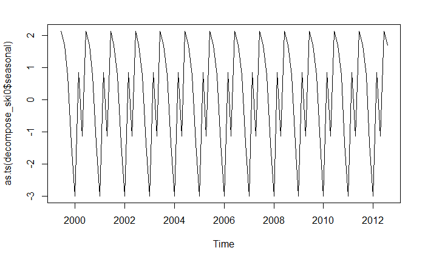

```r
library(fpp)
library(Ecdat)
ts_ski0 <- ts(data.set$Matched.DOW, start = c(1998, 11, 22), frequency = 7)
ts_ski1 <- ts(data.set$Actual.Demand[1:92], start = c(1999, 11, 22), frequency = 7)
decompose_ski0 = decompose(ts_ski0)
decompose_ski1 = decompose(ts_ski1)
#decompose_ski1 = decompose(ts_ski1, "additive")
plot(as.ts(decompose_ski0$seasonal))
```

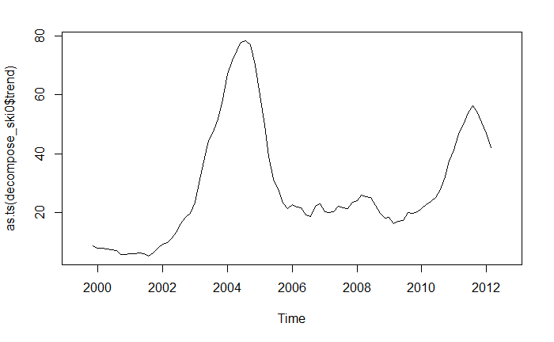

```r
plot(as.ts(decompose_ski0$trend))
```

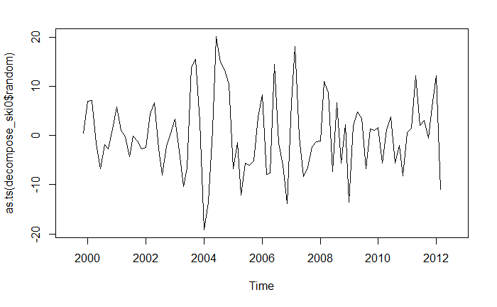

```r
plot(as.ts(decompose_ski0$random))
```

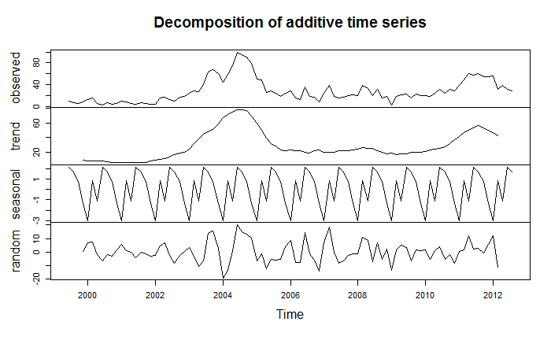

```r
plot(decompose_ski0)
```

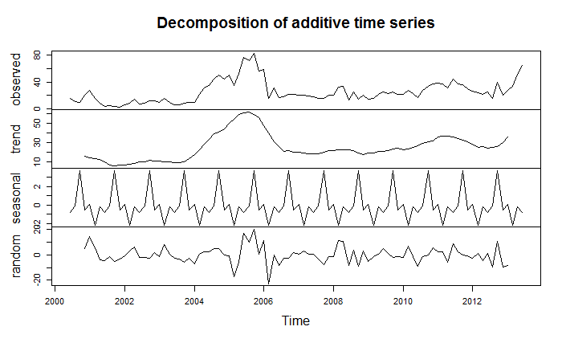

```r
plot(decompose_ski1)
```

### Using STL

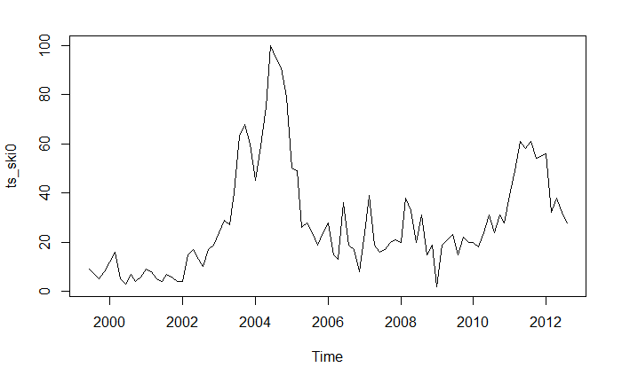

```r
stl_ski0 = stl(ts_ski0, "periodic")
seasonal_stl_ski0   <- stl_ski0$time.series[,1]
trend_stl_ski0     <- stl_ski0$time.series[,2]
random_stl_ski0  <- stl_ski0$time.series[,3]

plot(ts_ski0)
```

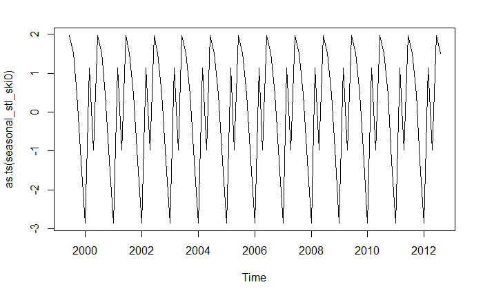

```r
plot(as.ts(seasonal_stl_ski0))
```

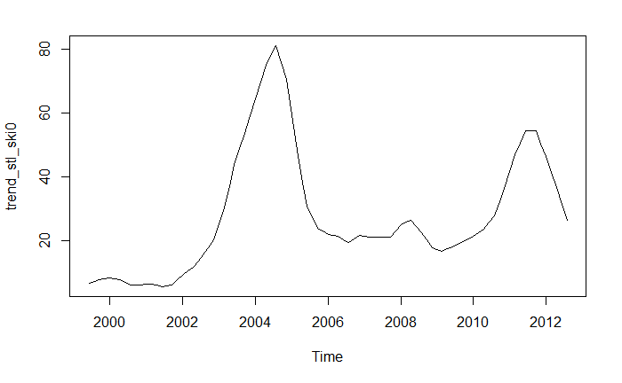

```r
plot(trend_stl_ski0)
```

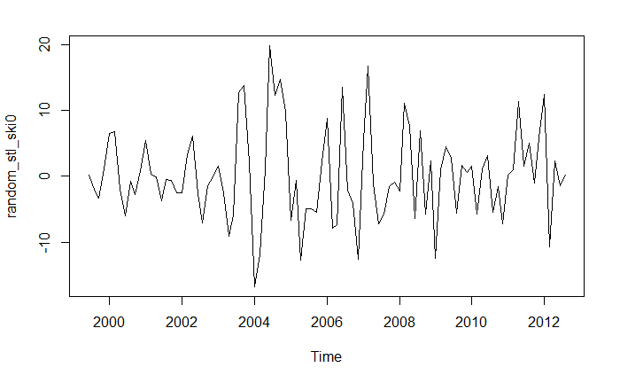

```r
plot(random_stl_ski0)
```

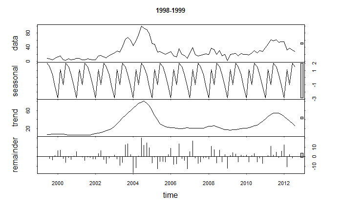

```r
plot(stl_ski0, main = "1998-1999")
```

#### Looks like some bigger error around christmas time and university break week

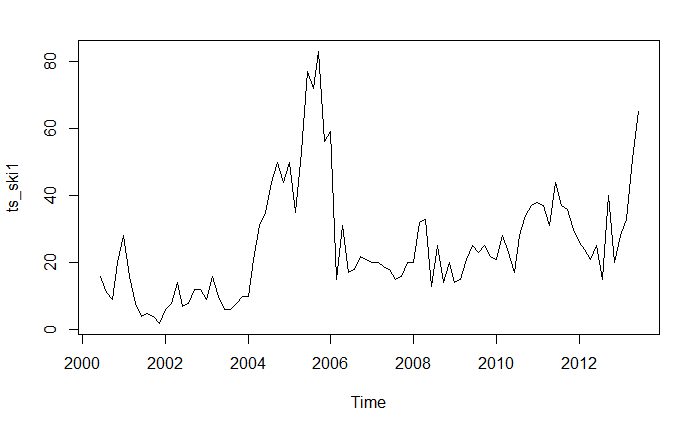

```r
stl_ski1 = stl(ts_ski1, "periodic")
seasonal_stl_ski1   <- stl_ski1$time.series[,1]
trend_stl_ski1     <- stl_ski1$time.series[,2]
random_stl_ski1  <- stl_ski1$time.series[,3]

plot(ts_ski1)
```

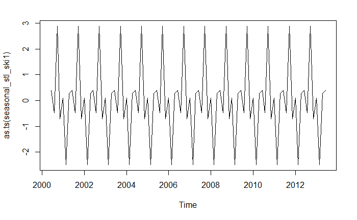

```r
plot(as.ts(seasonal_stl_ski1))
```

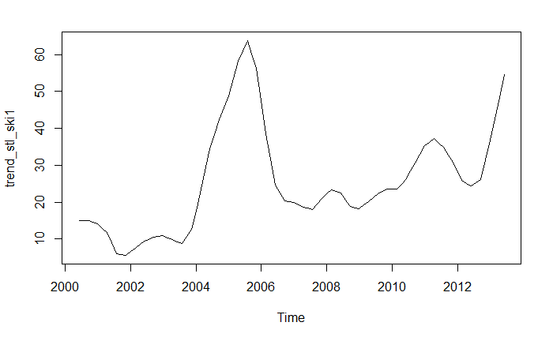

```r
plot(trend_stl_ski1)
```

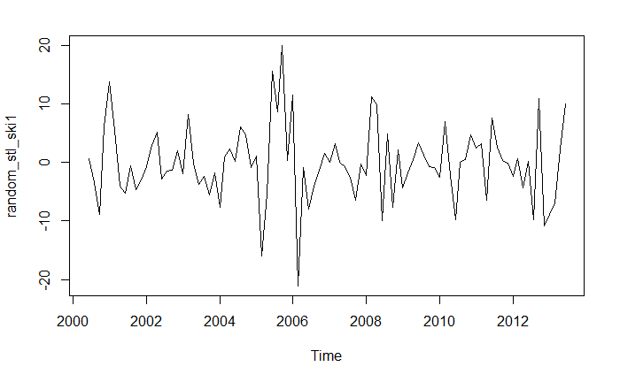

```r
plot(random_stl_ski1)
```

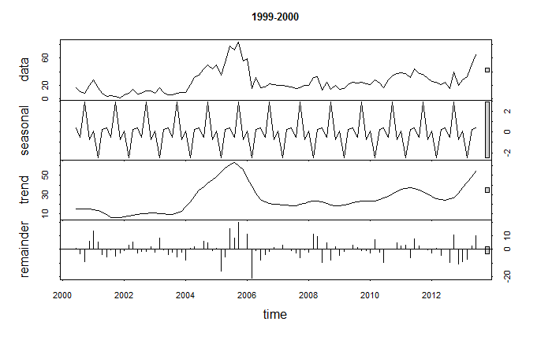

```r
plot(stl_ski1, main = "1999-2000")
```

# Link to Shiny app

[Link to shiny app](http://r.liamcorrigan.com:3838/)